# Importing Dataset

### SGD Classifier on RF Reduced Dataset

The final classifier to be tested was the stochastic gradient classifier.

```python
from sklearn.linear_model import SGDClassifier
```

```python
sgd=SGDClassifier()
params=dict(
    penalty = ['l2','l1','elasticnet'],
    alpha = [0.0001, 0.001, 0.01, 0.1, 1, 10],
    l1_ratio = [0, 0.1, 0.15, 0.2, 0.3, 0.4, 0.5, 0.6, 0.7, 0.8, 0.9]
)
gs = GridSearchCV(estimator=sgd, param_grid=params, cv=cv, n_jobs=-1, )
gs
gs.fit(X_train2, y_train2)
gs.best_params_
```

```
{'alpha': 0.01, 'l1_ratio': 0.7, 'penalty': 'elasticnet'}
```

```python
sgd=SGDClassifier(alpha=0.01,l1_ratio=0.3,penalty='elasticnet')
sgd.fit(X_train2,y_train2)
pred = sgd.predict(X_train2)
sgdTr = metrics.accuracy_score(y_true = y_train2, y_pred = pred)
print(sgdTr)
```

```
0.6695643174997413
```

```python
pred = sgd.predict(X_test2)
sgdTe = metrics.accuracy_score(y_true = y_test2, y_pred = pred)
print(sgdTe)
```

```
0.6477649006622517
```

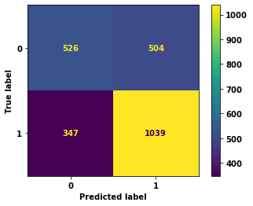

```python
plot_confusion_matrix(sgd,X_test2,y_test2)
plt.show()
```

```python
print(metrics.classification_report(y_test2, pred))
```

```
              precision    recall  f1-score   support

           0       0.60      0.51      0.55      1030
           1       0.67      0.75      0.71      1386

    accuracy                           0.65      2416
   macro avg       0.64      0.63      0.63      2416
weighted avg       0.64      0.65      0.64      2416
```

```python
sgdBa = metrics.balanced_accuracy_score(y_test2,pred)
print(sgdBa)
```

```
0.6301594306448676
```

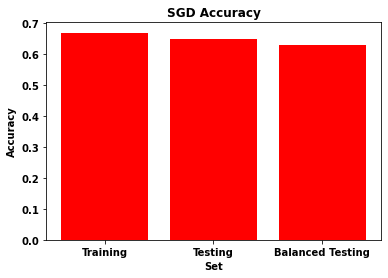

```python
labels=['Training', 'Testing', 'Balanced Testing']
accs=[sgdTr, sgdTe, sgdBa]
plt.bar(labels,accs,color='red')
plt.ylabel('Accuracy')
plt.xlabel('Set')
plt.title('SGD Accuracy')
plt.show()
```

### Overview of Models on RF Reduced Dataset

```python
lst=[['Random Forests 1',rfTr,rfTe,rfBa],
 ['Random Forests 2',rfTr2,rfTe2,rfBa2],
 ['Logistic Regression',lrTr,lrTe,lrBa],
 ['Decision Tree',dfTr,dfTe,dfBa],
 ['SGD Classifier',sgdTr,sgdTe,sgdBa]]

dfResults = pd.DataFrame(lst, columns =['Classifier','TrainAcc (%)','TestAcc (%)','BalancedTestAcc (%)'])
```

```python
dfResults
```

|  | Classifier | TrainAcc (%) | TestAcc (%) | BalancedTestAcc (%) |
| --- | --- | --- | --- | --- |
| 0 | Random Forests 1 | 0.957467 | 0.745861 | 0.731991 |
| 1 | Random Forests 2 | 0.787851 | 0.719371 | 0.696809 |
| 2 | Logistic Regression | 0.671945 | 0.643212 | 0.628061 |
| 3 | Decision Tree | 0.746145 | 0.703642 | 0.689708 |
| 4 | SGD Classifier | 0.669564 | 0.647765 | 0.630159 |

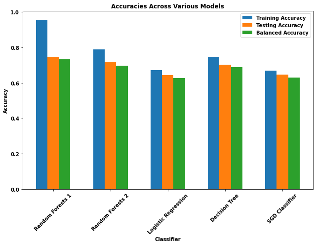

```python
labs=list(dfResults['Classifier'])
trAcc=list(dfResults['TrainAcc (%)'])
teAcc=list(dfResults['TestAcc (%)'])
btAcc=list(dfResults['BalancedTestAcc (%)'])

x=np.arange(len(labs))
width=0.20

fig,ax = plt.subplots(figsize=(9,7))
group1=ax.bar(x-width,trAcc,width,label='Training Accuracy')
group2=ax.bar(x,teAcc,width,label='Testing Accuracy')
group3=ax.bar(x+width,btAcc,width,label='Balanced Accuracy')

ax.set_ylabel('Accuracy')
ax.set_xlabel('Classifier')
ax.set_title('Accuracies Across Various Models')
ax.set_xticks(x)
ax.set_xticklabels(labs, rotation = 45)
ax.legend(bbox_to_anchor=(1, 1), loc='upper right', ncol=1)

fig.tight_layout()

plt.show()
```

### ROC Curves for RF Reduced Dataset Models

```python
from sklearn.metrics import precision_recall_curve, roc_curve
from sklearn import metrics
from sklearn.metrics import roc_curve, auc
from sklearn.metrics import roc_auc_score, plot_roc_curve
```

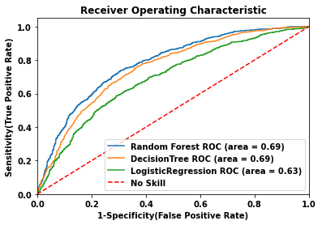

```python
models = [
{
    'label': 'Random Forest',
    'marker': 'o',
    'model': RandomForestClassifier(n_estimators=90, min_samples_leaf=5, max_depth=9),
},
{
    'label': 'DecisionTree',
    'marker': 'x',
    'model': DecisionTreeClassifier(criterion='entropy',min_samples_split=100),

},
{
    'label': 'LogisticRegression',
    'marker': '>',
    'model': LogisticRegression(C=0.1),
},
# {
#     'label': 'Stochastic gradient classifier',
#     'marker': '^',
#     'model': SGDClassifier(alpha=0.01,l1_ratio=0.3,penalty='elasticnet',loss='hinge'),
# }

]
# Below for loop iterates through your models list
for m in models:
    model = m['model'] # select the model
    model.fit(X_train2, y_train2) # train the model
    y_pred=model.predict(X_test2) # predict the test data
# Compute False postive rate, and True positive rate
    fpr, tpr, thresholds = metrics.roc_curve(y_test, model.predict_proba(X_test2)[:,1])
# Calculate Area under the curve to display on the plot
    auc = metrics.roc_auc_score(y_test2,model.predict(X_test2))
# Now, plot the computed values
    plt.plot(fpr, tpr, label='%s ROC (area = %0.2f)' % (m['label'], auc))
# Custom settings for the plot
plt.plot([0, 1], [0, 1],'r--',label='No Skill')
plt.xlim([0.0, 1.0])
plt.ylim([0.0, 1.05])
plt.xlabel('1-Specificity(False Positive Rate)')
plt.ylabel('Sensitivity(True Positive Rate)')
plt.title('Receiver Operating Characteristic')
plt.legend(loc="lower right")
plt.show()   # Display
```

##### Stochastic Gradient Descent Classifier

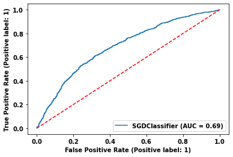

```python
# Compute ROC curve and ROC area for each class
sgd_roc = plot_roc_curve(sgd, X_test2, y_test2)
plt.plot([0, 1], [0, 1],'r--',label='No Skill')
plt.show()
```

From the ROC Curve, we got the similar value of area under the curve for Random Forest, Decision Tree, and SGD Classifier, while we got lower value with Logistic Regression.

# PCA Unsupervised Feature Selection & Model Building

```python
from sklearn.model_selection import train_test_split
X_train, X_test, y_train, y_test = train_test_split(X, y, test_size=0.2, random_state=27)
```

```python
from sklearn.decomposition import PCA
pca = PCA()
X_train_pca = pca.fit_transform(X_train)
X_test_pca = pca.transform(X_test)
```

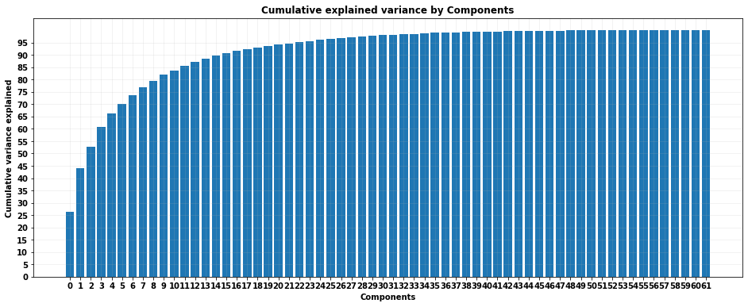

```python
plt.figure(figsize=(16,6))
plt.bar(x=range(len(pca.explained_variance_ratio_)),height=pca.explained_variance_ratio_.cumsum()*100)
plt.title("Cumulative explained variance by Components")
plt.xlabel("Components")
plt.ylabel("Cumulative variance explained")
plt.xticks(np.arange(pca.n_components_))
plt.yticks(np.arange(0,100,5))
plt.grid(alpha=0.2)
plt.show()
```

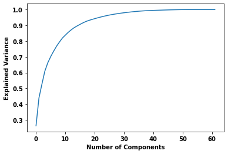

```python
plt.plot(np.cumsum(pca.explained_variance_ratio_))
plt.xlabel('Number of Components')
plt.ylabel('Explained Variance');
plt.show()
```

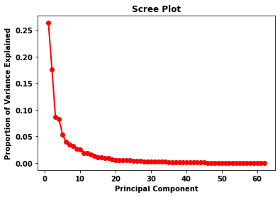

```python
PC_values = np.arange(pca.n_components_) + 1
plt.plot(PC_values, pca.explained_variance_ratio_, 'ro-', linewidth=2)
plt.title('Scree Plot')
plt.xlabel('Principal Component')
plt.ylabel('Proportion of Variance Explained')
plt.show()
```

```python
pca.explained_variance_ratio_[:22].sum()
```

```
0.9473969316431656
```

```python
pca = PCA(n_components=12)
X_train_pca = pca.fit_transform(X_train)
X_test_pca = pca.transform(X_test)
```

Since our goal for PCA is dimensionality reduction, we decided that the best method for determining the number of components would be choosing the number of components that give at approximately a 85% cumulative explained variance. Two versions of the scree plot are provided above as reference, but choosing the number based on the knee would not be appropriate for our purposes, as it would have a much smaller explained variance ratio that would have a drastic negative effect on model building accuracy, especially on the test set. 12 components will be used in the following models, as they give us ~85% explained variance.

### Random Forests on PCA Reduced Dataset

```python
rf=RandomForestClassifier()
params=dict(
    min_samples_split = [5, 10, 50, 100],
    max_depth = [1, 2, 3, 4, 5, 7, 10, None],
    n_estimators=[5, 10, 20, 30, 40, 50, 60, 70, 80, 90]
)
gs = GridSearchCV(estimator=rf, param_grid=params, cv=cv, n_jobs=-1, )
gs
gs.fit(X_train_pca, y_train2)
gs.best_params_
```

```
{'max_depth': None, 'min_samples_split': 10, 'n_estimators': 90}
```

Grid search found the optimal parameters to be min_samples_split: 10, n_estimators: 90, and max_depth: None

```python
rf=RandomForestClassifier(min_samples_split=10, n_estimators=90, max_depth=None)
rf.fit(X_train_pca,y_train2)
pred = rf.predict(X_train_pca)
rfTr2=metrics.accuracy_score(y_true = y_train2, y_pred = pred)
print(rfTr2)
```

```
0.9859256959536375
```

```python
pred = rf.predict(X_test_pca)
rfTe2=metrics.accuracy_score(y_true = y_test2, y_pred = pred)
print(rfTe2)
```

```
0.660182119205298
```

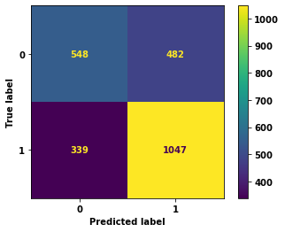

```python
plot_confusion_matrix(rf,X_test_pca,y_test2)
plt.show()
```

```python
print(metrics.classification_report(y_test2, pred))
```

```
              precision    recall  f1-score   support

           0       0.62      0.53      0.57      1030
           1       0.68      0.76      0.72      1386

    accuracy                           0.66      2416
   macro avg       0.65      0.64      0.65      2416
weighted avg       0.66      0.66      0.66      2416
```

```python
rfBa2=metrics.balanced_accuracy_score(y_test,pred)
print(rfBa2)
```

```
0.6437250451813559
```

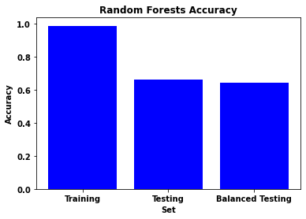

```python
labels=['Training', 'Testing', 'Balanced Testing']
accs=[rfTr2, rfTe2, rfBa2]
plt.bar(labels,accs,color='blue')
plt.ylabel('Accuracy')
plt.xlabel('Set')
plt.title('Random Forests Accuracy')
plt.show()
```

### Random Forest Max Depth Limit on PCA Reduced Dataset

```python
md_list = [1,2,3,4,5,6,7,8,9,10,11,12,13,14,15]
accuracy_train = []
accuracy_test = []
for md in md_list:
    rf_pca=RandomForestClassifier(max_depth=md,min_samples_split=10, n_estimators=90)
    rf_pca.fit(X_train_pca, y_train)

    pred=rf_pca.predict(X_train_pca)
    accuracy_train.append(metrics.accuracy_score(y_train, pred))

    pred=rf_pca.predict(X_test_pca)
    accuracy_test.append(metrics.accuracy_score(y_test, pred))
```

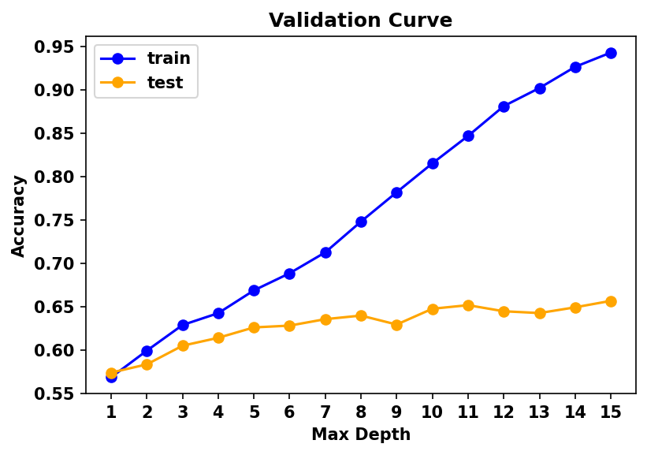

```python
f, ax = plt.subplots(dpi=150)
plt.plot(accuracy_train, marker='o', color='blue', label = 'train')
plt.plot(accuracy_test, marker='o',color='orange', label = 'test')
plt.title('Validation Curve')
plt.xticks(ticks=np.arange(len(md_list)), labels=md_list, rotation=0)
plt.xlabel('Max Depth')
plt.ylabel('Accuracy')
plt.legend()
plt.show()
```

We can see from the chart that we reach an optimum point in bias-variance tradeoff at about max_depth of 5 after this we do not see much improvement in test accuracy but training accuracy keep going up, we start moving towards the overfitting zone. Accuracy scores are significantly lower even after taking 12 components, which means PCA is not helping much with this dataset.

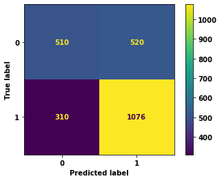

```python
plot_confusion_matrix(rf_pca,X_test_pca,y_test)
plt.show()
```

```python
rf=RandomForestClassifier(max_depth=5, min_samples_split=10, n_estimators=90)
rf.fit(X_train_pca,y_train2)
pred = rf.predict(X_train_pca)
rfTr3=metrics.accuracy_score(y_true = y_train2, y_pred = pred)
print(rfTr3)
```

```
0.6647004036013661
```

```python
pred = rf.predict(X_test_pca)
rfTe3=metrics.accuracy_score(y_true = y_test2, y_pred = pred)
print(rfTe3)
```

```
0.6212748344370861
```

```python
print(metrics.classification_report(y_test2, pred))
```

```
              precision    recall  f1-score   support

           0       0.61      0.30      0.40      1030
           1       0.62      0.86      0.72      1386

    accuracy                           0.62      2416
   macro avg       0.62      0.58      0.56      2416
weighted avg       0.62      0.62      0.59      2416
```

```python
rfBa3=metrics.balanced_accuracy_score(y_test2,pred)
print(rfBa3)
```

```
0.58001443001443
```

```python
tn, fp, fn, tp = metrics.confusion_matrix(y_test, pred).ravel()
recall_score = metrics.recall_score(y_test, pred)
specificity = tn / (tn+fp)
precision_score = metrics.precision_score(y_test, pred)
accuracy = metrics.accuracy_score(y_test, pred)
balanced_accuracy = metrics.balanced_accuracy_score(y_test, pred)
f1_score = metrics.f1_score(y_test, pred)
fpr = fp / (fp + tn)
print("\nMetrics on test data")
print('Recall Score :', round(recall_score,2))
print('Specificity :', round(specificity,2))
print('Precision Score :', round(precision_score,2))
print('Accuracy:', round(accuracy,2))
print('Balanced Accuracy:', round(balanced_accuracy,2))
print('F1 Score :', round(f1_score,2))
```

```
Metrics on test data
Recall Score : 0.86
Specificity : 0.3
Precision Score : 0.62
Accuracy: 0.62
Balanced Accuracy: 0.58
F1 Score : 0.72
```

### Logistic Regression on PCA Reduced Dataset

```python
lr=LogisticRegression(solver='liblinear')
params=dict(
    penalty=['l1','l2'],
    C=[0.001, 0.01, 0.1, 1, 10, 100],
    class_weight=[None, 'balanced']
)
gs = GridSearchCV(estimator=lr, param_grid=params, cv=cv, n_jobs=-1, )
gs
gs.fit(X_train_pca, y_train2)
gs.best_params_
```

```
{'C': 10, 'class_weight': None, 'penalty': 'l1'}
```

```python
lr=LogisticRegression(C=10, penalty='l1',solver='liblinear')
lr.fit(X_train_pca,y_train2)
pred = lr.predict(X_train_pca)
lrTr2 = metrics.accuracy_score(y_true = y_train2, y_pred = pred)
print(lrTr2)
```

```
0.6287902307771913
```

```python
pred = lr.predict(X_test_pca)
lrTe2 = metrics.accuracy_score(y_true = y_test2, y_pred = pred)
print(lrTe2)
```

```
0.609271523178808
```

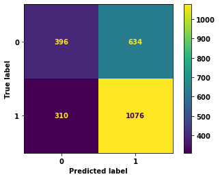

```python
plot_confusion_matrix(lr,X_test_pca,y_test2)
plt.show()
```

```python
print(metrics.classification_report(y_test2, pred))
```

```
              precision    recall  f1-score   support

           0       0.56      0.38      0.46      1030
           1       0.63      0.78      0.70      1386

    accuracy                           0.61      2416
   macro avg       0.60      0.58      0.58      2416
weighted avg       0.60      0.61      0.59      2416
```

```python
lrBa2 = metrics.balanced_accuracy_score(y_test2,pred)
print(lrBa2)
```

```
0.5804003978761261
```

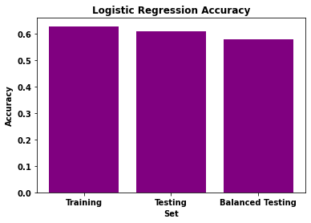

```python
labels=['Training', 'Testing', 'Balanced Testing']
accs=[lrTr2, lrTe2, lrBa2]
plt.bar(labels,accs,color='purple')
plt.ylabel('Accuracy')
plt.xlabel('Set')
plt.title('Logistic Regression Accuracy')
plt.show()
```

### Decision Trees on PCA Reduced Dataset

```python
df=DecisionTreeClassifier()
params=dict(
    min_samples_split = [5, 10, 50, 100],
    max_depth = [1, 2, 3, 4, 5, 7, 10, None],
    criterion=['entropy','gini']
)
gs = GridSearchCV(estimator=df, param_grid=params, cv=cv, n_jobs=-1, )
gs
gs.fit(X_train_pca, y_train2)
gs.best_params_
```

```
{'criterion': 'entropy', 'max_depth': 10, 'min_samples_split': 100}
```

```python
df=DecisionTreeClassifier(criterion='gini',min_samples_split=100, max_depth=7)
df.fit(X_train_pca,y_train2)
pred = df.predict(X_train_pca)
dfTr2=metrics.accuracy_score(y_true = y_train2, y_pred = pred)
print(dfTr2)
```

```
0.6744282313981165
```

```python
pred = df.predict(X_test_pca)
dfTe2=metrics.accuracy_score(y_true = y_test2, y_pred = pred)
print(dfTe2)
```

```
0.6084437086092715
```

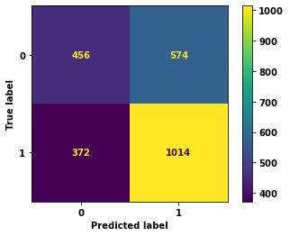

```python
plot_confusion_matrix(df,X_test_pca,y_test2)
plt.show()
```

```python
print(metrics.classification_report(y_test2, pred))
```

```
              precision    recall  f1-score   support

           0       0.55      0.44      0.49      1030
           1       0.64      0.73      0.68      1386

    accuracy                           0.61      2416
   macro avg       0.59      0.59      0.59      2416
weighted avg       0.60      0.61      0.60      2416
```

```python
dfBa2=metrics.balanced_accuracy_score(y_test2,pred)
print(dfBa2)
```

```
0.5871600891018367
```

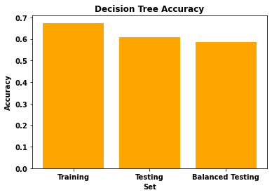

```python
labels=['Training', 'Testing', 'Balanced Testing']
accs=[dfTr2, dfTe2, dfBa2]
plt.bar(labels,accs,color='orange')
plt.ylabel('Accuracy')
plt.xlabel('Set')
plt.title('Decision Tree Accuracy')
plt.show()
```

### SGD Classifier on PCA Reduced Dataset

```python
sgd=SGDClassifier()
params=dict(
    penalty = ['l2','l1','elasticnet'],
    alpha = [0.0001, 0.001, 0.01, 0.1, 1, 10],
    l1_ratio = [0, 0.1, 0.15, 0.2, 0.3, 0.4, 0.5, 0.6, 0.7, 0.8, 0.9]
)
gs = GridSearchCV(estimator=sgd, param_grid=params, cv=cv, n_jobs=-1, )
gs
gs.fit(X_train_pca, y_train2)
gs.best_params_
```

```
{'alpha': 0.01, 'l1_ratio': 0.2, 'penalty': 'elasticnet'}
```

```python
sgd=SGDClassifier(alpha=0.01,l1_ratio=0.1,penalty='l2')
sgd.fit(X_train_pca,y_train2)
pred = sgd.predict(X_train_pca)
sgdTr2 = metrics.accuracy_score(y_true = y_train2, y_pred = pred)
print(sgdTr2)
```

```
0.6237193418193108
```

```python
pred = sgd.predict(X_test_pca)
sgdTe2 = metrics.accuracy_score(y_true = y_test2, y_pred = pred)
print(sgdTe2)
```

```
0.6076158940397351
```

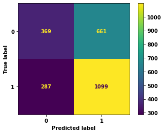

```python
plot_confusion_matrix(sgd,X_test_pca,y_test2)
plt.show()
```

```python
print(metrics.classification_report(y_test2, pred))
```

```
              precision    recall  f1-score   support

           0       0.56      0.36      0.44      1030
           1       0.62      0.79      0.70      1386

    accuracy                           0.61      2416
   macro avg       0.59      0.58      0.57      2416
weighted avg       0.60      0.61      0.59      2416
```

```python
sgdBa2 = metrics.balanced_accuracy_score(y_test2,pred)
print(sgdBa2)
```

```
0.5755908600568795
```

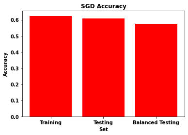

```python
labels=['Training', 'Testing', 'Balanced Testing']
accs=[sgdTr2, sgdTe2, sgdBa2]
plt.bar(labels,accs,color='red')
plt.ylabel('Accuracy')
plt.xlabel('Set')
plt.title('SGD Accuracy')
plt.show()
```

### Overview of Models on PCA Reduced Dataset

```python
lst=[['Random Forests 1',rfTr2,rfTe2,rfBa2],
 ['Random Forests 2',rfTr3,rfTe3,rfBa3],
 ['Logistic Regression',lrTr2,lrTe2,lrBa2],
 ['Decision Tree',dfTr2,dfTe2,dfBa2],
 ['SGD Classifier',sgdTr2,sgdTe2,sgdBa2]]

dfResults2 = pd.DataFrame(lst, columns =['Classifier','TrainAcc (%)','TestAcc (%)','BalancedTestAcc (%)'])
```

```python
dfResults2
```

|  | Classifier | TrainAcc (%) | TestAcc (%) | BalancedTestAcc (%) |
| --- | --- | --- | --- | --- |
| 0 | Random Forests 1 | 0.985926 | 0.660182 | 0.643725 |
| 1 | Random Forests 2 | 0.664700 | 0.621275 | 0.580014 |
| 2 | Logistic Regression | 0.628790 | 0.609272 | 0.580400 |
| 3 | Decision Tree | 0.674428 | 0.608444 | 0.587160 |
| 4 | SGD Classifier | 0.623719 | 0.607616 | 0.575591 |

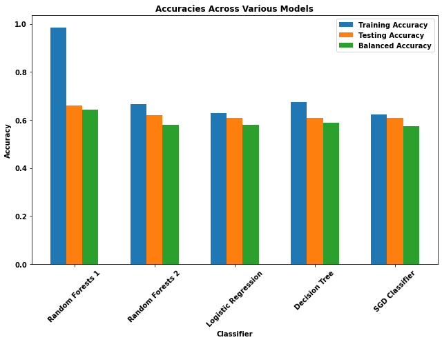

```python
labs=list(dfResults2['Classifier'])
trAcc=list(dfResults2['TrainAcc (%)'])
teAcc=list(dfResults2['TestAcc (%)'])
btAcc=list(dfResults2['BalancedTestAcc (%)'])

x=np.arange(len(labs))
width=0.20

fig,ax = plt.subplots(figsize=(9,7))
group1=ax.bar(x-width,trAcc,width,label='Training Accuracy')
group2=ax.bar(x,teAcc,width,label='Testing Accuracy')
group3=ax.bar(x+width,btAcc,width,label='Balanced Accuracy')

ax.set_ylabel('Accuracy')
ax.set_xlabel('Classifier')
ax.set_title('Accuracies Across Various Models')
ax.set_xticks(x)
ax.set_xticklabels(labs, rotation = 45)
ax.legend(bbox_to_anchor=(1, 1), loc='upper right', ncol=1)

fig.tight_layout()

plt.show()
```

# Overall Conclusions

Presenting coupons to a customer can be a very efficient and cheap way of attracting them to a business or service. The acceptance of a coupon is likely to increase traffic to a business and is bound to drive sales. Our supervised feature selection technique revealed that through 17 variables, it is quite possible to predict a consumers behavior. Again, these variables include temperature, time, age, has_children, education, income, Bar, CoffeeHouse, CarryAway, RestaurantLessThan20, Restaurant20To50, toCoupon_GEQ15min, coupon_Bar, coupon_Carry out & Take away, coupon_Coffee House, coupon_Restaurant(<20), expiration_1d.

# Clustering

#### We would have normalized the data so that all attributes are in the same scale (between 0 and 1), but our values are not that bing especially when we are dealing with ordinal variables.

```python
# min_max_scaler = preprocessing.MinMaxScaler().fit(vs_train)
vs_train_norm = np.array(X_train)
vs_test_norm = np.array(X_test)
vs_train_copy = X_train.copy()
```

```python
print(X_train.shape)
X_train[0:5]  # display the first five records
```

```
(9663, 62)
```

|  | temperature | time | age | has_children | education | income | Bar | CoffeeHouse | CarryAway | RestaurantLessThan20 | ... | occupation_Management | occupation_Office & Administrative Support | occupation_Personal Care & Service | occupation_Production Occupations | occupation_Protective Service | occupation_Retired | occupation_Sales & Related | occupation_Student | occupation_Transportation & Material Moving | occupation_Unemployed |
| --- | --- | --- | --- | --- | --- | --- | --- | --- | --- | --- | --- | --- | --- | --- | --- | --- | --- | --- | --- | --- | --- |
| 447 | 1 | 0 | 2 | 0 | 4 | 4 | 0 | 2 | 2 | 1 | ... | 0 | 0 | 0 | 0 | 0 | 0 | 0 | 0 | 0 | 0 |
| 11832 | 0 | 1 | 7 | 1 | 3 | 1 | 1 | 1 | 3 | 2 | ... | 0 | 0 | 0 | 0 | 0 | 0 | 0 | 0 | 0 | 0 |
| 4956 | 2 | 0 | 3 | 0 | 1 | 2 | 2 | 0 | 3 | 2 | ... | 0 | 0 | 0 | 1 | 0 | 0 | 0 | 0 | 0 | 0 |
| 6030 | 1 | 2 | 2 | 0 | 2 | 3 | 1 | 1 | 1 | 2 | ... | 1 | 0 | 0 | 0 | 0 | 0 | 0 | 0 | 0 | 0 |
| 6808 | 2 | 3 | 2 | 0 | 2 | 1 | 0 | 1 | 2 | 3 | ... | 0 | 0 | 0 | 0 | 0 | 0 | 0 | 0 | 0 | 1 |

5 rows × 62 columns

```python
print(X_test.shape)
X_test[0:5] # display the first five records
```

```
(2416, 62)
```

|  | temperature | time | age | has_children | education | income | Bar | CoffeeHouse | CarryAway | RestaurantLessThan20 | ... | occupation_Management | occupation_Office & Administrative Support | occupation_Personal Care & Service | occupation_Production Occupations | occupation_Protective Service | occupation_Retired | occupation_Sales & Related | occupation_Student | occupation_Transportation & Material Moving | occupation_Unemployed |
| --- | --- | --- | --- | --- | --- | --- | --- | --- | --- | --- | --- | --- | --- | --- | --- | --- | --- | --- | --- | --- | --- |
| 468 | 1 | 0 | 3 | 1 | 1 | 4 | 4 | 4 | 4 | 4 | ... | 1 | 0 | 0 | 0 | 0 | 0 | 0 | 0 | 0 | 0 |
| 5043 | 1 | 2 | 1 | 0 | 4 | 1 | 1 | 2 | 4 | 4 | ... | 0 | 0 | 0 | 0 | 0 | 0 | 0 | 0 | 0 | 0 |
| 8870 | 2 | 4 | 2 | 0 | 5 | 3 | 3 | 2 | 3 | 2 | ... | 0 | 0 | 0 | 0 | 0 | 0 | 0 | 0 | 0 | 0 |
| 3235 | 2 | 2 | 3 | 0 | 1 | 2 | 0 | 2 | 2 | 2 | ... | 0 | 0 | 0 | 0 | 0 | 0 | 0 | 0 | 0 | 0 |
| 397 | 1 | 2 | 1 | 0 | 4 | 8 | 2 | 0 | 2 | 2 | ... | 0 | 0 | 0 | 0 | 0 | 0 | 0 | 1 | 0 | 0 |

5 rows × 62 columns

### Using Kmodes with cao initialization

```python
kmode_cl =KModes(n_clusters = 2, init = 'cao', n_init = 1, verbose = 1)
```

[output not shown]

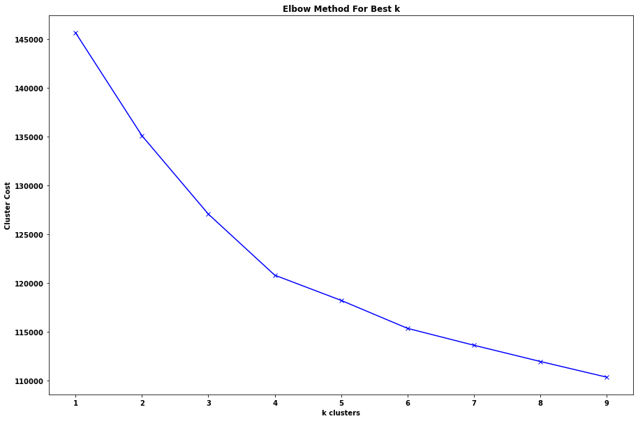

```python
%time
cluster_cost = []
K = range(1,10)
for num in list(K):

    kmode_cl =KModes(n_clusters = num, init = 'cao', n_init = 1)
    kmode_cl.fit_predict(vs_train_norm)
    cluster_cost.append(kmode_cl.cost_)

plt.figure(figsize=[15, 10])
plt.plot(K, cluster_cost, 'bx-')
plt.xlabel('k clusters')
plt.ylabel('Cluster Cost')
plt.title('Elbow Method For Best k')
plt.show()
```

Our best k is going to be either 3 or 4 so we shall both values.

### when k = 4

```python
kmode_cl = KModes(n_clusters = 4, init = 'cao', n_init = 1, verbose = 1)
labels = kmode_cl.fit_predict(vs_train_norm)
labels
```

```
Init: initializing centroids
Init: initializing clusters
Starting iterations...
Run 1, iteration: 1/100, moves: 3405, cost: 121175.0
Run 1, iteration: 2/100, moves: 805, cost: 120807.0
Run 1, iteration: 3/100, moves: 268, cost: 120807.0
```

```
array([2, 0, 2, ..., 2, 0, 1], dtype=uint16)
```

#### let's assign the different cluster labels to our the vs_train data set when k = 4

```python
X_train['cluster'] = labels
# vs_train['cluster'].value_counts()
```

```python
print('Cluster ClusterSize:')
X_train['cluster'].value_counts()
```

```
Cluster ClusterSize:
```

```
0    3362
2    2198
1    2163
3    1940
Name: cluster, dtype: int64
```

When k = 4, we get the following cluster sizes of the different clusters:

```python
# when k = 3
kmode_cl = KModes(n_clusters = 3, init = 'cao', n_init = 1)
labels = kmode_cl.fit_predict(vs_train_norm)
labels
```

```
array([2, 0, 2, ..., 2, 0, 1], dtype=uint16)
```

#### let's assign the different cluster labels to our the vs_train data set when k = 3

```python
X_train['cluster_K3'] = labels
```

```python
print('Cluster ClusterSize:')
X_train['cluster_K3'].value_counts()
```

```
Cluster ClusterSize:
```

```
0    4807
2    2535
1    2321
Name: cluster_K3, dtype: int64
```

When k = 3, we get the following cluster sizes of the different clusters:

#### Let's measure the homogenity and completness when k is either 3 or 4 to determine whick k gives us the best clusters

```python
# when k = 4
label_k4 = X_train['cluster'].astype(int)
label_k4[0:4] # display the first 3 records
```

```
447      2
11832    0
4956     2
6030     3
Name: cluster, dtype: int32
```

#### let's convert vs_target_train into a numpy array

```python
vs_target_train_array = np.array(y_train)
```

```python
print(completeness_score(vs_target_train_array, label_k4))
```

```
0.0027698200972415938
```

```python
print(homogeneity_score(vs_target_train_array, label_k4))
```

```
0.0055151304096035005
```

The completeness score doesn't approach 1 when most of the data points that are members of a given class are elements of the same class.

The same that applies to the homogeneity score; it doesn't approach 1 when all the clusters contain almost only data points that are member of a single class.

The scores we got are extremely too low.

### when k = 3

```python
# when k = 3
label_k3 = X_train['cluster_K3'].astype(int)
label_k3[0:4] # display the first 3 records
```

```
447      2
11832    0
4956     2
6030     0
Name: cluster_K3, dtype: int32
```

```python
print(completeness_score(vs_target_train_array, label_k3))
```

```
0.0022473928642685274
```

```python
print(homogeneity_score(vs_target_train_array, label_k3))
```

```
0.003421290206469697
```

The completeness score doesn't approach 1 when most of the data points that are members of a given class are elements of the same class.

The same that applies to the homogeneity score; it doesn't approach 1 when all the clusters contain almost only data points that are member of a single class.

The scores we got are extremely too low.

### We shall look at the K - prototype

```python
 categoricalds = X_train[['time', 'age', 'income', 'Restaurant20To50', 'RestaurantLessThan20', 'CarryAway', 'CoffeeHouse', 'Bar', 'education', 'temperature']]
```

```python
categoricalds_array = np.array(categoricalds)
```

```python
categoricalds.info()
```

```
<class 'pandas.core.frame.DataFrame'>
Int64Index: 9663 entries, 447 to 5377
Data columns (total 10 columns):
 #   Column                Non-Null Count  Dtype
---  ------                --------------  -----
 0   time                  9663 non-null   object
 1   age                   9663 non-null   object
 2   income                9663 non-null   object
 3   Restaurant20To50      9663 non-null   object
 4   RestaurantLessThan20  9663 non-null   object
 5   CarryAway             9663 non-null   object
 6   CoffeeHouse           9663 non-null   object
 7   Bar                   9663 non-null   object
 8   education             9663 non-null   object
 9   temperature           9663 non-null   int64
dtypes: int64(1), object(9)
memory usage: 830.4+ KB
```

#### Tuning a K prototype model based on time, age, income and Restaurant20To50

```
Wall time: 0 ns
```

```
<function matplotlib.pyplot.show(close=None, block=None)>
```

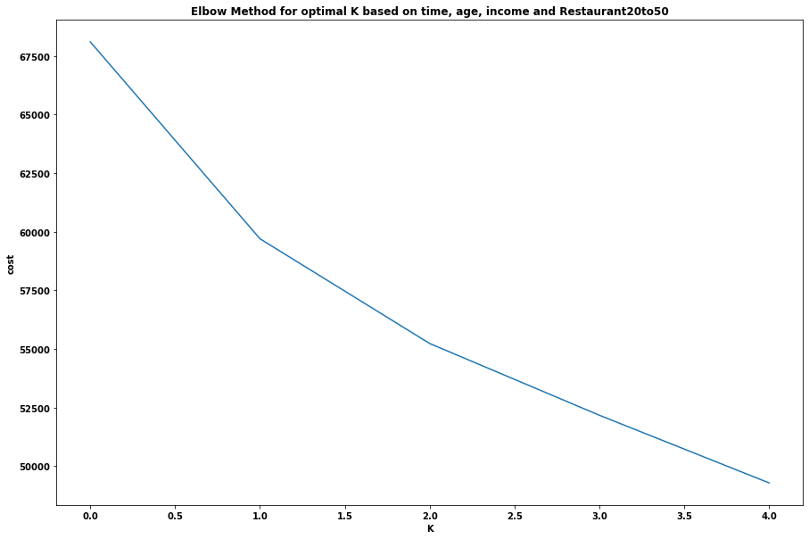

```python
%time
#Choosing optimal K value
cost = []
X = categoricalds_array
for num_clusters in list(range(2,7)):
    kproto = KPrototypes(n_clusters=num_clusters, max_iter=15) # we run for 15 iterations until it converges
    kproto.fit_predict(X, categorical=[0, 1, 2, 3])
    cost.append(kproto.cost_)

plt.figure(figsize=[15, 10])
plt.plot(cost)
plt.xlabel('K')
plt.ylabel('cost')
plt.title('Elbow Method for optimal K based on time, age, income and Restaurant20to50')
plt.show
```

K Prototype uses the frequency based method to update the mode in the clustering process and the mode is used to minimize the clustering cost function and with support for both Kmeans and k Prototype for categorical data, it is able to continously work on both continous and categorical data. When it is continous, it is going to be the mean and when it is categorical, it will be the mode where it uses a based frequency similarity measure.

### when k = 3

```python
 KProto = KPrototypes(n_clusters=3,  max_iter=15)
```

```python
klabels_3 = KProto.fit_predict(X, categorical=[0, 1, 2, 3])
klabels_3
```

```
array([1, 0, 0, ..., 1, 1, 2], dtype=uint16)
```

#### Let's assign the cluster labels to the vs_train data set wken k = 3:

```python
X_train['kPrototype_3'] =  KProto.labels_
```

```python
print('Cluster Cluster sizes when  k = 3:')
X_train['kPrototype_3'].value_counts()
```

```
Cluster Cluster sizes when  k = 3:
```

```
0    3986
1    2950
2    2727
Name: kPrototype_3, dtype: int64
```

When k = 3, we get the following cluster sizes of the different clusters:

#### Let's measure the homogenity and completenes when k = 3:

```python
completeness_score(vs_target_train_array, X_train['kPrototype_3'])
```

```
0.004680248263108886
```

```python
homogeneity_score(vs_target_train_array, X_train['kPrototype_3'])
```

```
0.0074229824792386235
```

Both the completeness and homogeneity scores are extremely low.

### when k = 2

```python
KProto = KPrototypes(n_clusters=2,  max_iter=15)
```

```python
klabels_2 = KProto.fit_predict(X, categorical=[0, 1, 2, 3])
klabels_2
```

```
array([1, 1, 1, ..., 1, 0, 0], dtype=uint16)
```

```python
clusters_k2 = [i for i in klabels_2]
```

#### Let's assign the cluster labels to the vs_train data set wken k = 2:

```python
X_train['kPrototype_2'] = clusters_k2
```

```python
print('Cluster Cluster sizes when  k = 2:')
X_train['kPrototype_2'].value_counts()
```

```
Cluster Cluster sizes when  k = 2:
```

```
1    6030
0    3633
Name: kPrototype_2, dtype: int64
```

When k = 2, we get the following cluster sizes of the different clusters:

#### Let's measure the homogenity and completenes when k = 2:

```python
label_kPrototyp_2 = X_train['kPrototype_2']
```

```python
completeness_score(vs_target_train_array, label_kPrototyp_2)
```

```
0.004351416120001989
```

```python
homogeneity_score(vs_target_train_array, label_kPrototyp_2)
```

```
0.0042130400144430955
```

Both the completeness and homogeneity scores are too low for when k = 2.

### when = 6

```python
KProto = KPrototypes(n_clusters=6,  max_iter=15)
```

```python
klabels_6 = KProto.fit_predict(X, categorical=[0, 1, 2, 3])
klabels_6
```

```
array([3, 0, 0, ..., 5, 2, 5], dtype=uint16)
```

#### Let's assign the cluster labels to the vs_train data set when k = 6

```python
X_train['kPrototype_6'] =  KProto.labels_
```

```python
print('Cluster Cluster sizes when  k = 6:')
X_train['kPrototype_6'].value_counts()
```

```
Cluster Cluster sizes when  k = 6:
```

```
1    2230
3    2109
2    1613
0    1554
5    1133
4    1024
Name: kPrototype_6, dtype: int64
```

When k = 6, we get the following cluster sizes of the different clusters:

#### Let's measure the homogenity and completenes when k = 6:

```python
label_kPrototyp_2 = X_train['kPrototype_6']
```

```python
completeness_score(vs_target_train_array, label_kPrototyp_2)
```

```
0.0025433664391207853
```

```python
homogeneity_score(vs_target_train_array, label_kPrototyp_2)
```

```
0.006518335822976002
```

Both the completeness and homogeneity scores are extremely low.

Since our scores for both completeness and homogeneity are too low, we are going to take the features of importance derived from random forests and get a subset of the data for those features.

```python
vs_train_important_features = X_train[['temperature','time', 'age', 'has_children', 'education', 'income','Bar', 'CoffeeHouse'
, 'CarryAway', 'RestaurantLessThan20', 'Restaurant20To50', 'toCoupon_GEQ15min', 'coupon_Bar'
, 'coupon_Carry out & Take away', 'coupon_Coffee House', 'coupon_Restaurant(<20)', 'expiration_1d']]
```

```python
vs_train_important_features
```

|  | temperature | time | age | has_children | education | income | Bar | CoffeeHouse | CarryAway | RestaurantLessThan20 | Restaurant20To50 | toCoupon_GEQ15min | coupon_Bar | coupon_Carry out & Take away | coupon_Coffee House | coupon_Restaurant(<20) | expiration_1d |
| --- | --- | --- | --- | --- | --- | --- | --- | --- | --- | --- | --- | --- | --- | --- | --- | --- | --- |
| 447 | 1 | 0 | 2 | 0 | 4 | 4 | 0 | 2 | 2 | 1 | 1 | 1 | 1 | 0 | 0 | 0 | 1 |
| 11832 | 0 | 1 | 7 | 1 | 3 | 1 | 1 | 1 | 3 | 2 | 1 | 0 | 0 | 0 | 0 | 1 | 1 |
| 4956 | 2 | 0 | 3 | 0 | 1 | 2 | 2 | 0 | 3 | 2 | 1 | 1 | 0 | 0 | 1 | 0 | 0 |
| 6030 | 1 | 2 | 2 | 0 | 2 | 3 | 1 | 1 | 1 | 2 | 1 | 0 | 0 | 0 | 1 | 0 | 1 |
| 6808 | 2 | 3 | 2 | 0 | 2 | 1 | 0 | 1 | 2 | 3 | 1 | 0 | 0 | 0 | 1 | 0 | 0 |
| ... | ... | ... | ... | ... | ... | ... | ... | ... | ... | ... | ... | ... | ... | ... | ... | ... | ... |
| 7518 | 0 | 4 | 5 | 1 | 2 | 0 | 0 | 2 | 2 | 3 | 1 | 0 | 0 | 0 | 0 | 0 | 0 |
| 5086 | 2 | 3 | 1 | 0 | 1 | 2 | 1 | 2 | 3 | 2 | 1 | 1 | 0 | 0 | 0 | 1 | 1 |
| 4107 | 1 | 0 | 1 | 0 | 4 | 0 | 2 | 1 | 3 | 2 | 1 | 1 | 0 | 0 | 1 | 0 | 1 |
| 3963 | 2 | 3 | 1 | 0 | 4 | 1 | 0 | 2 | 4 | 2 | 2 | 1 | 0 | 0 | 0 | 1 | 0 |
| 5377 | 2 | 3 | 2 | 0 | 4 | 8 | 3 | 2 | 2 | 2 | 1 | 0 | 0 | 0 | 1 | 0 | 1 |

9663 rows × 17 columns

```python
vs_train_important_features.corr().round(decimals = 2)
```

|  | temperature | has_children | toCoupon_GEQ15min | coupon_Bar | coupon_Carry out & Take away | coupon_Coffee House | coupon_Restaurant(<20) | expiration_1d |
| --- | --- | --- | --- | --- | --- | --- | --- | --- |
| temperature | 1.00 | -0.02 | -0.15 | -0.12 | -0.13 | 0.17 | 0.03 | -0.12 |
| has_children | -0.02 | 1.00 | 0.08 | 0.02 | 0.02 | -0.04 | -0.01 | -0.01 |
| toCoupon_GEQ15min | -0.15 | 0.08 | 1.00 | 0.09 | 0.08 | -0.05 | -0.13 | -0.05 |
| coupon_Bar | -0.12 | 0.02 | 0.09 | 1.00 | -0.21 | -0.30 | -0.23 | 0.19 |
| coupon_Carry out & Take away | -0.13 | 0.02 | 0.08 | -0.21 | 1.00 | -0.33 | -0.26 | 0.04 |
| coupon_Coffee House | 0.17 | -0.04 | -0.05 | -0.30 | -0.33 | 1.00 | -0.36 | -0.15 |
| coupon_Restaurant(<20) | 0.03 | -0.01 | -0.13 | -0.23 | -0.26 | -0.36 | 1.00 | -0.09 |
| expiration_1d | -0.12 | -0.01 | -0.05 | 0.19 | 0.04 | -0.15 | -0.09 | 1.00 |

All these variables have either a negative or positive weak correlation with each other and where the correlation values are 0, there is no correlation at all.

```python
# let's convert the data into a numpy array
vs_train_important_features_array = np.array(vs_train_important_features)
```

#### Lets try again building a kmode cluster on the sub-selected data set.

```
Wall time: 0 ns
```

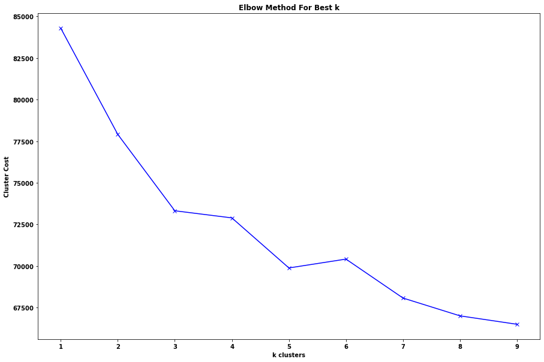

```python
%time
cluster_cost = []
K = range(1,10)
for num in list(K):

    kmode_cl =KModes(n_clusters = num, init = 'random', max_iter=15)
    kmode_cl.fit_predict(vs_train_important_features_array)
    cluster_cost.append(kmode_cl.cost_)

plt.figure(figsize=[15, 10])
plt.plot(K, cluster_cost, 'bx-')
plt.xlabel('k clusters')
plt.ylabel('Cluster Cost')
plt.title('Elbow Method For Best k')
plt.show()
```

Our best k is likely to be 3, but we shall also try 4 and 5.

```python
# when k = 4
kmode_cl =KModes(n_clusters = 4, init = 'random', max_iter=15)
labels_4 = kmode_cl.fit_predict(vs_train_important_features_array)
```

```python
clusters_k4 = [i for i in labels_4]
```

```python
labels_4
```

```
array([1, 1, 0, ..., 1, 0, 0], dtype=uint16)
```

#### Let's create a copy of the vs_train_important_features data set

```python
vs_train_important_features_view = vs_train_important_features.copy()
```

#### Let's assign the different cluster labels to the subselected data set

```python
vs_train_important_features_view['clusters_k4'] = clusters_k4
```

```python
print('Cluster ClusterSizes')
vs_train_important_features_view['clusters_k4'].value_counts()
```

```
Cluster ClusterSizes
```

```
0    3692
1    3292
3    1727
2     952
Name: clusters_k4, dtype: int64
```

#### Let's measure the homogenity and completenes when k = 4

```python
cluster_label_4 = vs_train_important_features_view['clusters_k4']
```

```python
completeness_score(vs_target_train_array, cluster_label_4)
```

```
0.0017574116968185887
```

```python
homogeneity_score(vs_target_train_array, cluster_label_4)
```

```
0.0032653210789142435
```

Both the completeness and homogeneity scores are too low for when k = 4.

#### Building a k mode cluster when k = 5

```python
# when k = 5
kmode_cl =KModes(n_clusters = 5, init = 'random',  max_iter=15)
labels_5 = kmode_cl.fit_predict(vs_train_important_features_array)
```

```python
clusters_k5 = [i for i in labels_5]
```

#### Creating another copy of the vs_train_important_features data set

```python
vs_train_important_features_view2 = vs_train_important_features.copy()
```

#### Let's assign the different cluster labels to the subselected data set

```python
vs_train_important_features_view2['clusters_k5'] = clusters_k5
```

```python
print('Cluster ClusterSizes')
vs_train_important_features_view2['clusters_k5'].value_counts()
```

```
Cluster ClusterSizes
```

```
1    2976
0    2295
3    1600
4    1412
2    1380
Name: clusters_k5, dtype: int64
```

#### Let's measure the homogenity and completenes when k = 5

```python
cluster_label_5 = vs_train_important_features_view2['clusters_k5']
```

```python
completeness_score(vs_target_train_array, cluster_label_5)
```

```
0.002126451045954677
```

```python
homogeneity_score(vs_target_train_array, cluster_label_5)
```

```
0.004853977683783868
```

Using the features of importance sub-selected data set, both the completeness and homogeneity scores are too low for when k = 5.

#### Lets's build a KPrototype cluster model based on education.

```
Wall time: 0 ns
```

```
<function matplotlib.pyplot.show(close=None, block=None)>
```

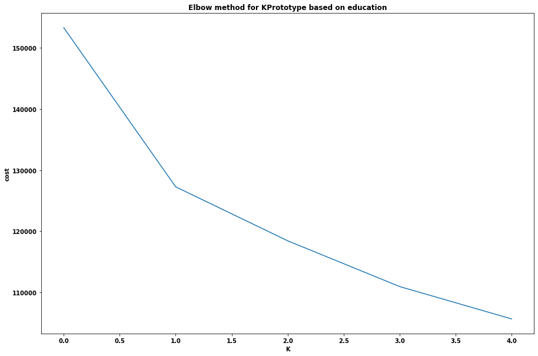

```python
%time
#Choosing optimal K value
cost = []
X = vs_train_important_features_array
for num_clusters in list(range(2,7)):
    kproto = KPrototypes(n_clusters=num_clusters,  max_iter=15) # we run for 15 iterations until it converges
    kproto.fit_predict(X, categorical=[4])
    cost.append(kproto.cost_)

plt.figure(figsize=[15, 10])
plt.plot(cost)
plt.xlabel('K')
plt.ylabel('cost')
plt.title('Elbow method for KPrototype based on education')
plt.show
```

Our best optimal K is likely to be 3.

```python
# let's build a KPrototype cluster model when k = 3
kproto = KPrototypes(n_clusters=3,  max_iter=15)
Klabels3 = kproto.fit_predict(X, categorical=[4])
```

#### let's reconstruct a list of clusters to be assigned as cluster labels to the vs_train_important_features_view data set:

```python
clusters_k3 = [i for i in Klabels3]
```

#### let's assign the list of cluster labels to the vs_train_important_features_view data set.

```python
vs_train_important_features_view['clusterLabel_k3'] = clusters_k3
```

```python
print('Cluster Cluster sizes when k = 3')
vs_train_important_features_view['clusterLabel_k3'].value_counts()
```

```
Cluster Cluster sizes when k = 3
```

```
1    4171
2    3045
0    2447
Name: clusterLabel_k3, dtype: int64
```

#### Let's measure the homogenity and completeness when k = 3 basing one categorical feature:

```python
completeness_score(vs_target_train_array, vs_train_important_features_view['clusterLabel_k3'])
```

```
0.0016476469054072746
```

```python
homogeneity_score(vs_target_train_array, vs_train_important_features_view['clusterLabel_k3'])
```

```
0.0025886879424962222
```

Both the completeness and homogeneity scores don't make any difference from what we have seen before, the numbers we are getting here are still low.

#### Using Huang Initialization, let's build the KPrototype model based on age

```
Wall time: 0 ns
```

```
<function matplotlib.pyplot.show(close=None, block=None)>
```

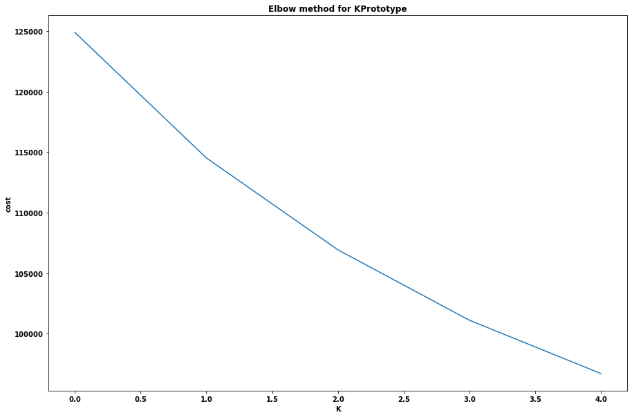

```python
%time
#Choosing optimal K value
cost = []
X = vs_train_important_features_array
for num_clusters in list(range(2,7)):
    kproto = KPrototypes(n_clusters=num_clusters, init='Huang', max_iter=8) # we run for 8 iterations until it converges
    kproto.fit_predict(X, categorical=[2])
    cost.append(kproto.cost_)

plt.figure(figsize=[15, 10])
plt.plot(cost)
plt.xlabel('K')
plt.ylabel('cost')
plt.title('Elbow method for KPrototype')
plt.show
```

#### Our best K is either 2 or 3 so we shall try both values.

#### when k = 2

```python
kproto = KPrototypes(n_clusters = 2, init='Huang', max_iter=8) # we run for 8 iterations until it converges
Kproto_labels_2 = kproto.fit_predict(X, categorical=[2])
```

#### let's reconstruct a list of clusters to be assigned as cluster labels to the vs_train_important_features_view data set:

```python
Kproto_labels_2L = [i for i in Kproto_labels_2]
```

#### let's assign the list of cluster labels to the vs_train_important_features_view data set.

```python
vs_train_important_features_view['clusterLabel_H2'] = Kproto_labels_2L
```

```python
print('Cluster Cluster sizes when k = 2')
vs_train_important_features_view['clusterLabel_H2'].value_counts()
```

```
Cluster Cluster sizes when k = 2
```

```
1    6311
0    3352
Name: clusterLabel_H2, dtype: int64
```

#### Let's measure the completeness and homogeneity

```python
completeness_score(vs_target_train_array, vs_train_important_features_view['clusterLabel_H2'])
```

```
0.0014825808365070078
```

```python
homogeneity_score(vs_target_train_array, vs_train_important_features_view['clusterLabel_H2'])
```

```
0.0013995373875639408
```

Both the completeness and homogeneity scores don't make any difference from what we have seen before, the numbers we are getting here are still low.

#### when k = 3

```python
kproto = KPrototypes(n_clusters = 3, init='Huang', max_iter=8) # we run for 8 iterations until it converges
Kproto_labels_3 = kproto.fit_predict(X, categorical=[2])
```

#### let's reconstruct a list of clusters to be assigned as cluster labels to the vs_train_important_features_view data set:

```python
Kproto_labels_3L = [i for i in Kproto_labels_3]
```

#### let's assign the list of cluster labels to the vs_train_important_features_view data set.

```python
vs_train_important_features_view['clusterLabel_H3'] = Kproto_labels_3L
```

```python
print('Cluster Cluster sizes when k = 3')
vs_train_important_features_view['clusterLabel_H3'].value_counts()
```

```
Cluster Cluster sizes when k = 3
```

```
0    3591
1    3282
2    2790
Name: clusterLabel_H3, dtype: int64
```

#### Let's measure the completeness and homogeneity

```python
completeness_score(vs_target_train_array, vs_train_important_features_view['clusterLabel_H3'])
```

```
0.0011395699897085582
```

```python
homogeneity_score(vs_target_train_array, vs_train_important_features_view['clusterLabel_H3'])
```

```
0.0018220176733659366
```

Both the completeness and homogeneity scores don't make any difference from what we have seen before since the numbers we are getting here are still low

## Using KMedoids:

### Where the goal is to find medoids that minimize the sum of absolute distance to the closest medoid.

#### when k = 2:

```python
KMedoids_cl = KMedoids(n_clusters = 2, random_state = 0)
KMedoids_cl.fit(X)
labels = KMedoids_cl.fit_predict(X)
```

```python
labels
```

```
array([0, 0, 0, ..., 0, 0, 1], dtype=int64)
```

#### Let's make a copy of the vs_train data set

```python
vs_train_KM = X_train.copy()
```

#### let's assign the cluster labels to the vs_train_KM data set.

```python
vs_train_KM['Clusters_KM2'] = KMedoids_cl.labels_
```

```python
print('Cluster Cluster sizes when k = 2')
vs_train_KM['Clusters_KM2'].value_counts()
```

```
Cluster Cluster sizes when k = 2
```

```
0    5931
1    3732
Name: Clusters_KM2, dtype: int64
```

#### Let's measure the completeness and homogeneity

```python
completeness_score(vs_target_train_array, vs_train_KM['Clusters_KM2'])
```

```
0.0020079435141966513
```

```python
homogeneity_score(vs_target_train_array, vs_train_KM['Clusters_KM2'])
```

```
0.001958679376075712
```

#### when k = 3

```python
KMedoids_cl = KMedoids(n_clusters = 3, random_state = 0)
KMedoids_cl.fit(X)
labels = KMedoids_cl.fit_predict(X)
```

#### let's assign the cluster labels to the vs_train_KM data set.

```python
vs_train_KM['Clusters_KM3'] = KMedoids_cl.labels_
```

```python
print('Cluster Cluster sizes when k = 3')
vs_train_KM['Clusters_KM3'].value_counts()
```

```
Cluster Cluster sizes when k = 3
```

```
0    4632
2    3661
1    1370
Name: Clusters_KM3, dtype: int64
```

#### Let's measure the completeness and homogeneity

```python
completeness_score(vs_target_train_array, vs_train_KM['Clusters_KM3'])
```

```
0.0015315711918069768
```

```python
homogeneity_score(vs_target_train_array, vs_train_KM['Clusters_KM3'])
```

```
0.0022334172911364493
```

# Clustering Conclusion:

Since the results of these clustering methods were inconclusive as to specific groups of consumers being formed, we suspect that there might be some bias in our data set and this is something that needs to be investigated.